# model_fitting

Zhaokun Lin

2025-11-30

# Data Preparation

## Data Wrangling (wenjie)

```r
# Import data & data cleaning
cirrhosis <- read.csv("data/cirrhosis.csv") |> clean_names()

# Status convert to event indicator (1 = death, 0 = censored)
cirrhosis <- cirrhosis |>
  mutate(
    event = case_when(
      status == "D" ~ 1,
      status %in% c("C", "CL") ~ 0,
      TRUE ~ NA_real_
    ),
    sex = factor(sex),
    drug = factor(drug),
    ascites = factor(ascites),
    hepatomegaly = factor(hepatomegaly),
    spiders = factor(spiders),
    edema = factor(edema, levels = c("N", "S", "Y"), ordered = TRUE),
    stage = factor(stage) # Yixin: "Stage: histologic stage of disease (1, 2, 3, or 4)"
  )

cirrhosis <- cirrhosis |>
  mutate(age_years = age / 365.25)
```

## Model fitting(Zhaokun)

```r
cirr_trial <- cirrhosis |>
  filter(!is.na(drug))

cirr_trial <- cirr_trial |>
  mutate(
    log_bilirubin  = log(bilirubin),
    # log_platelets   = log(platelets),
    # log_prothrombin = log(prothrombin)
  )

cirr_trial <- cirr_trial |>
  mutate(
    edema_bin = case_when(
      edema == "N" ~ 0L,
      edema %in% c("S", "Y") ~ 1L,
      TRUE ~ NA_integer_
    )
  )

# Missing values per variable in RCT (drug non-missing)
trial_missing <- cirr_trial %>%
  summarise(across(
    .cols = everything(),
    .fns  = ~ sum(is.na(.)),
    .names = "n_miss_{.col}"
  )) %>%
  pivot_longer(
    cols = everything(),
    names_to = "variable",
    values_to = "n_missing"
  ) %>%
  mutate(
    variable    = sub("^n_miss_", "", variable),
    pct_missing = round(n_missing / nrow(cirr_trial) * 100, 1)
  ) %>%
  arrange(desc(n_missing))

trial_missing
```

```
## # A tibble: 24 × 3
##    variable      n_missing pct_missing
##    <chr>             <int>       <dbl>
##  1 tryglicerides        30         9.6
##  2 cholesterol          28         9
##  3 platelets             4         1.3
##  4 copper                2         0.6
##  5 id                    0         0
##  6 n_days                0         0
##  7 status                0         0
##  8 drug                  0         0
##  9 age                   0         0
## 10 sex                   0         0
## # ℹ 14 more rows
```

```r
knitr::kable(trial_missing, caption = "Missing values per variable in RCT (drug non-missing)")
```

Missing values per variable in RCT (drug non-missing)

| variable | n_missing | pct_missing |
| --- | --- | --- |
| tryglicerides | 30 | 9.6 |
| cholesterol | 28 | 9.0 |
| platelets | 4 | 1.3 |
| copper | 2 | 0.6 |
| id | 0 | 0.0 |
| n_days | 0 | 0.0 |
| status | 0 | 0.0 |
| drug | 0 | 0.0 |
| age | 0 | 0.0 |
| sex | 0 | 0.0 |
| ascites | 0 | 0.0 |
| hepatomegaly | 0 | 0.0 |
| spiders | 0 | 0.0 |
| edema | 0 | 0.0 |
| bilirubin | 0 | 0.0 |
| albumin | 0 | 0.0 |
| alk_phos | 0 | 0.0 |
| sgot | 0 | 0.0 |
| prothrombin | 0 | 0.0 |
| stage | 0 | 0.0 |
| event | 0 | 0.0 |
| age_years | 0 | 0.0 |
| log_bilirubin | 0 | 0.0 |
| edema_bin | 0 | 0.0 |

Tryglicerides and cholesterol has lots of missing value, and platelets has 4, copper has 2, so we choose to drop tryglicerides and cholesterol

```r
# fit model
vars_main <- c(
  "id", "n_days", "event",
  "drug", "age_years",
  "log_bilirubin", "albumin", "prothrombin",
  "sex", "ascites", "edema_bin",
  "platelets", "copper",
  "stage"
)

cirr_main <- cirr_trial |>
  select(all_of(vars_main)) |>
  drop_na()

fit_main <- coxph(
  Surv(n_days, event) ~
    drug +
    age_years +
    log_bilirubin + albumin + prothrombin +
    sex + ascites + edema_bin + platelets + copper +
    strata(stage),
  data = cirr_main
)
summary(fit_main)
```

```
## Call:
## coxph(formula = Surv(n_days, event) ~ drug + age_years + log_bilirubin +
##     albumin + prothrombin + sex + ascites + edema_bin + platelets +
##     copper + strata(stage), data = cirr_main)
##
##   n= 306, number of events= 123
##
##                     coef  exp(coef)   se(coef)      z Pr(>|z|)
## drugPlacebo    0.1712537  1.1867918  0.1928762  0.888  0.37460
## age_years      0.0253059  1.0256288  0.0096776  2.615  0.00893 **
## log_bilirubin  0.8097184  2.2472750  0.1184310  6.837 8.08e-12 ***
## albumin       -0.7759352  0.4602731  0.2655637 -2.922  0.00348 **
## prothrombin    0.2734636  1.3145096  0.1039162  2.632  0.00850 **
## sexM           0.2457104  1.2785293  0.3003179  0.818  0.41326
## ascitesY       0.0198512  1.0200495  0.3155971  0.063  0.94985
## edema_bin      0.4552685  1.5765966  0.2494238  1.825  0.06796 .
## platelets     -0.0005514  0.9994488  0.0009936 -0.555  0.57895
## copper         0.0015681  1.0015693  0.0011443  1.370  0.17059
## ---
## Signif. codes:  0 '***' 0.001 '**' 0.01 '*' 0.05 '.' 0.1 ' ' 1
##
##               exp(coef) exp(-coef) lower .95 upper .95
## drugPlacebo      1.1868     0.8426    0.8132    1.7320
## age_years        1.0256     0.9750    1.0064    1.0453
## log_bilirubin    2.2473     0.4450    1.7818    2.8344
## albumin          0.4603     2.1726    0.2735    0.7746
## prothrombin      1.3145     0.7607    1.0723    1.6115
## sexM             1.2785     0.7821    0.7097    2.3033
## ascitesY         1.0200     0.9803    0.5495    1.8935
## edema_bin        1.5766     0.6343    0.9670    2.5706
## platelets        0.9994     1.0006    0.9975    1.0014
## copper           1.0016     0.9984    0.9993    1.0038
##
## Concordance= 0.803  (se = 0.025 )
## Likelihood ratio test= 145.8  on 10 df,   p=<2e-16
## Wald test            = 139.5  on 10 df,   p=<2e-16
## Score (logrank) test = 176.6  on 10 df,   p=<2e-16
```

```r
# ph test
ph_test <- cox.zph(fit_main)
ph_test
```

```
##                  chisq df     p
## drug           0.75859  1 0.384
## age_years      0.20286  1 0.652
## log_bilirubin  1.82019  1 0.177
## albumin        0.00673  1 0.935
## prothrombin    4.10527  1 0.043
## sex            0.06422  1 0.800
## ascites        0.01102  1 0.916
## edema_bin      6.62252  1 0.010
## platelets      0.25451  1 0.614
## copper         0.41949  1 0.517
## GLOBAL        15.24852 10 0.123
```

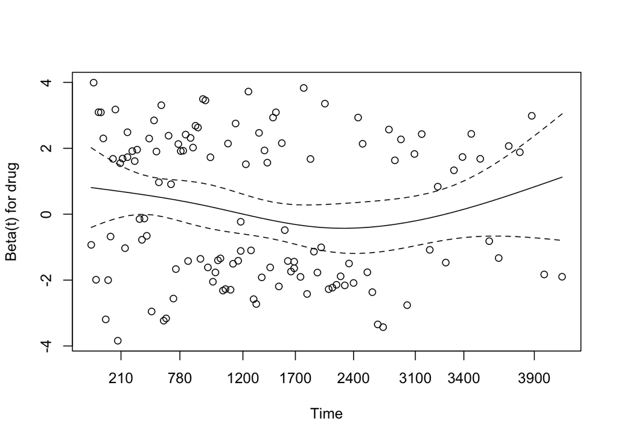

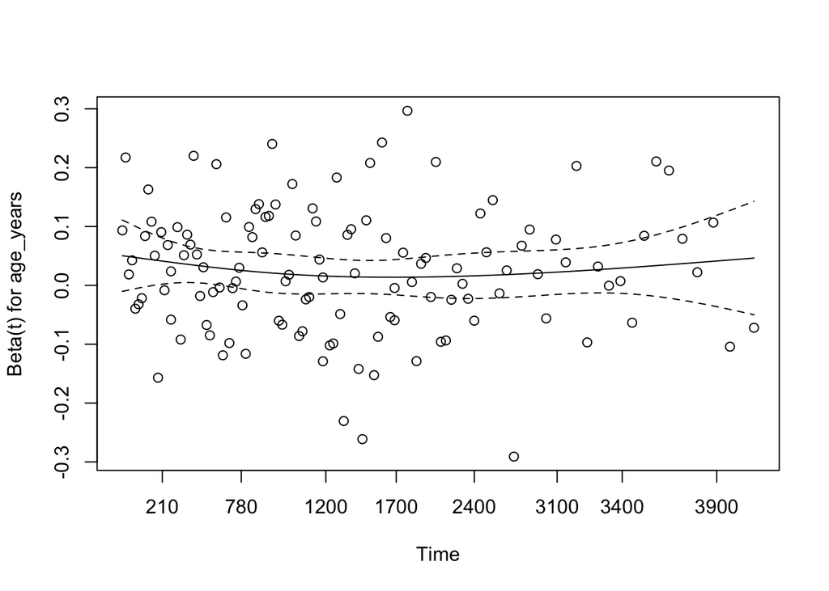

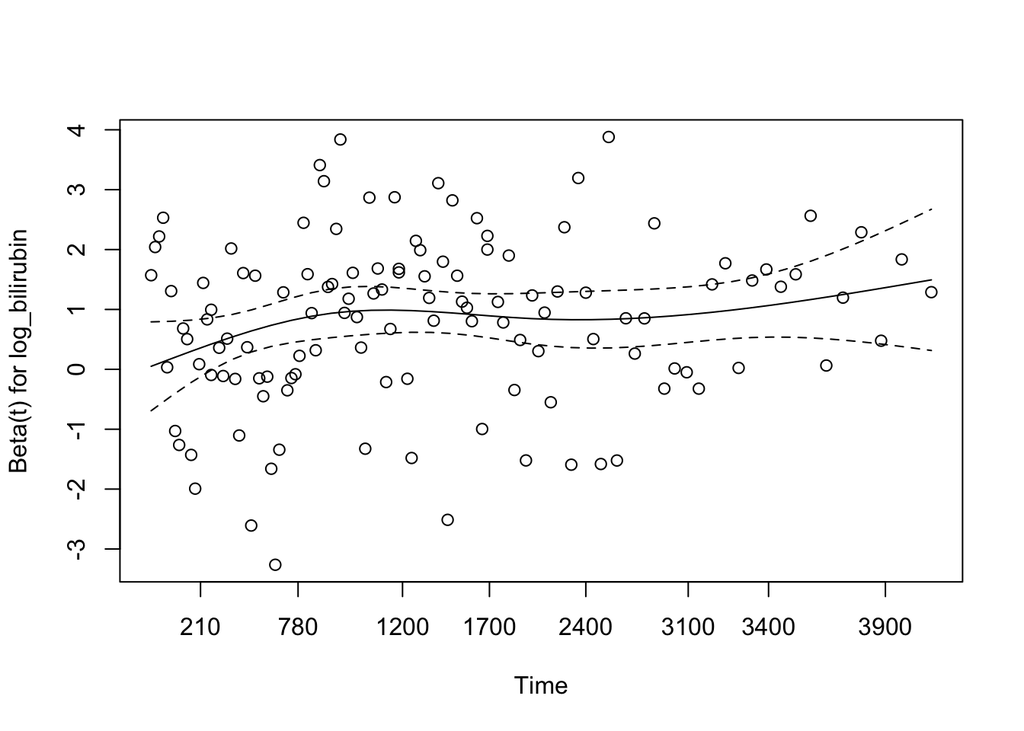

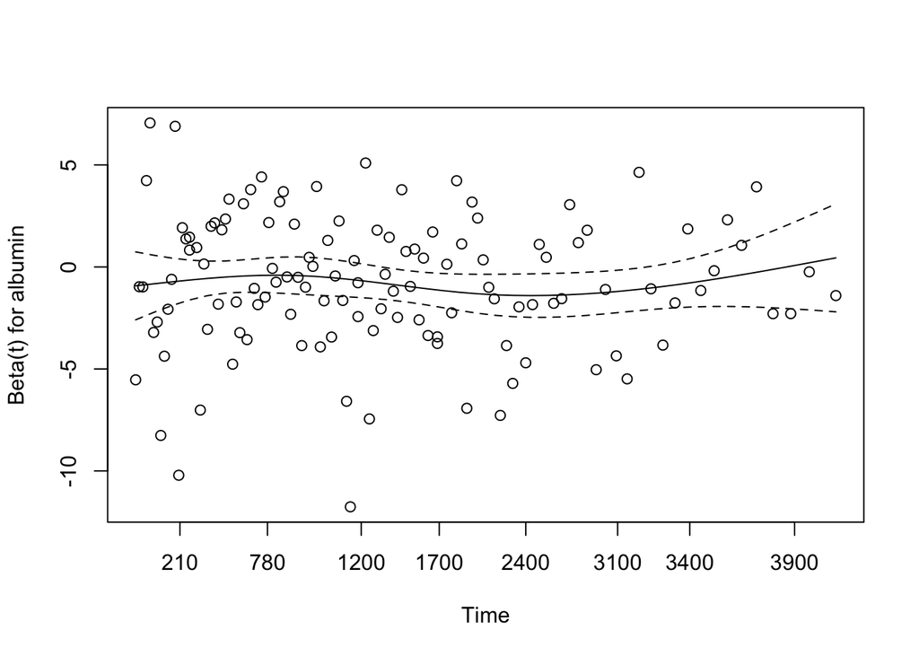

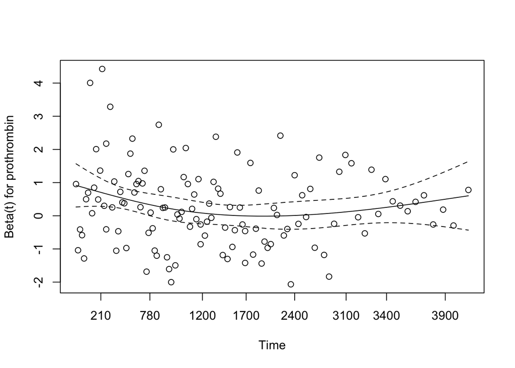

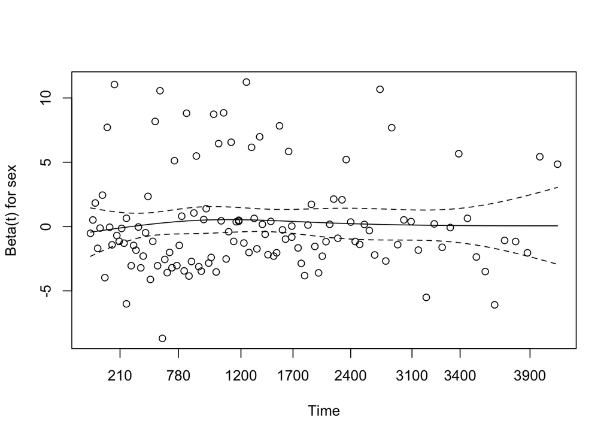

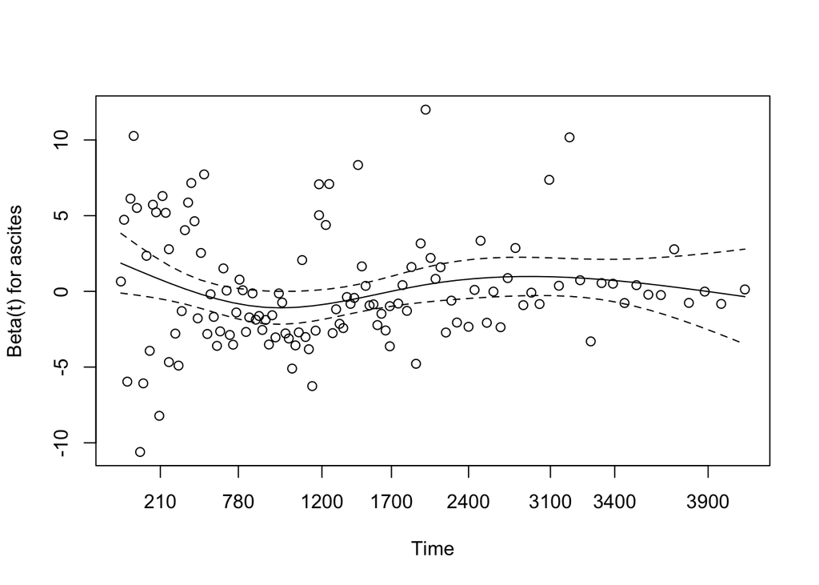

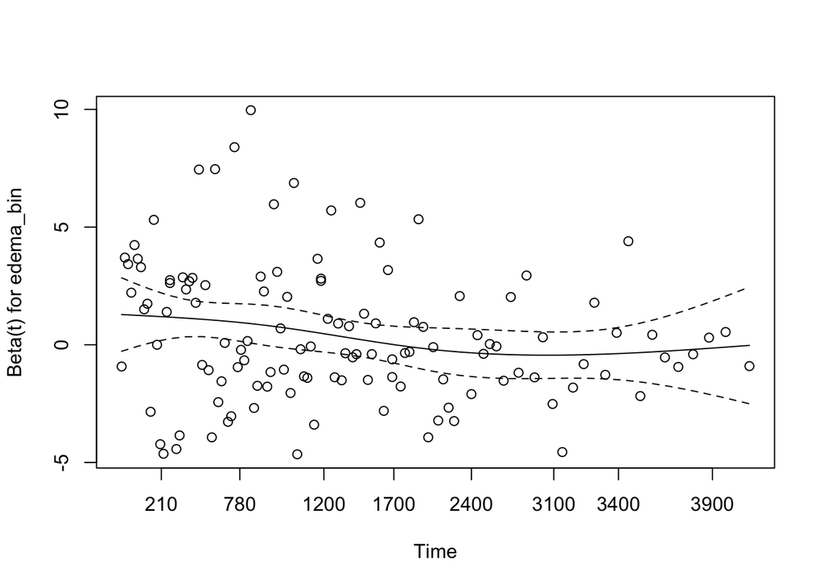

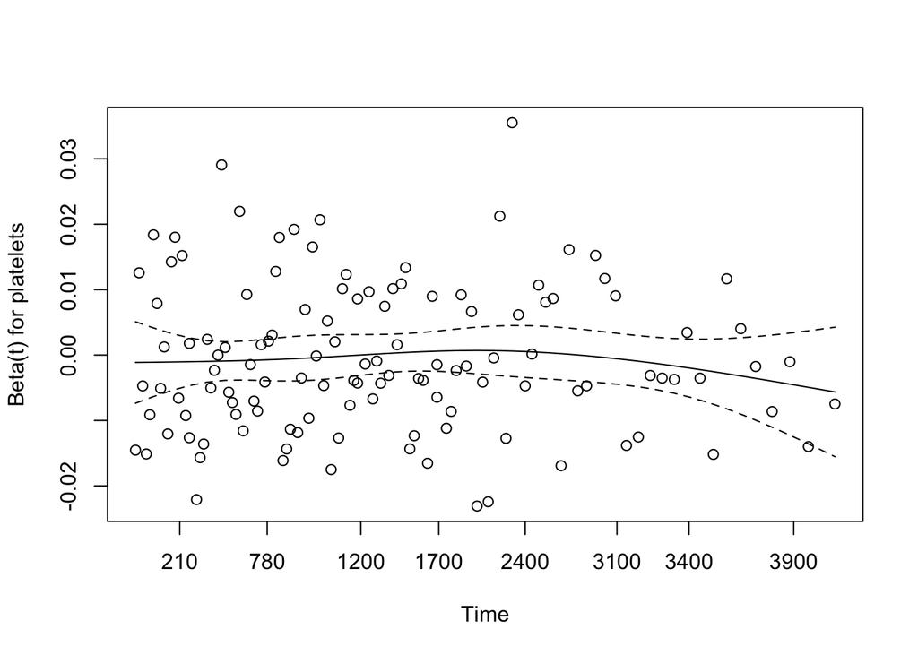

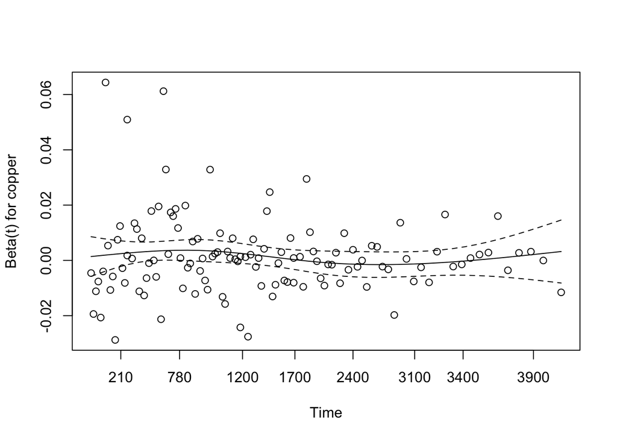

```r
plot(ph_test)
```

The proportional hazards assumption was evaluated using scaled Schoenfeld residuals. In the `cox.zph` table, the global test (χ² = 15.25 on 10 df, p = 0.123) does not provide strong evidence against the proportional hazards assumption for the model as a whole. For most covariates—including treatment (drug), age, log-bilirubin, albumin, sex, ascites, platelets, and copper—the p-values are comfortably above 0.10, suggesting that their effects on the log-hazard can be regarded as approximately constant over time. Two variables stand out: prothrombin (p ≈ 0.043) and edema_bin (p ≈ 0.010), which show some statistical evidence that their effects may vary with time and are mainly responsible for the mild global deviation.

The Schoenfeld residual plots provide a graphical check of the same assumption. For each covariate, the smoothed curve of the residuals over time is close to a horizontal line around zero when proportional hazards holds. For drug, age_years, log_bilirubin, albumin, sex, ascites, platelets, and copper, the smoothed lines are nearly flat and remain within the confidence bands without any clear upward or downward trend, which visually supports the proportional hazards assumption. In contrast, the plots for prothrombin and edema_bin show gentle curvature over time rather than perfectly flat lines, consistent with their smaller p-values. These patterns suggest that the hazard ratios associated with prothrombin and edema may change slightly during follow-up, but the deviations appear modest rather than dramatic.

Overall, the diagnostics indicate that the Cox model satisfies the proportional hazards assumption reasonably well. The main parameters of interest—especially the treatment effect—do not exhibit meaningful time-varying behavior, and the mild non-proportionality seen for prothrombin and edema is unlikely to materially alter the estimated treatment effect, though it can be acknowledged as a limitation or explored further in sensitivity analyses.

## Variable selection

can drop sex/ascites/platelets/copper

```r
fit_no_copper <- update(fit_main, . ~ . - copper)
anova(fit_main, fit_no_copper, test = "LRT")
```

```
## Analysis of Deviance Table
##  Cox model: response is  Surv(n_days, event)
##  Model 1: ~ drug + age_years + log_bilirubin + albumin + prothrombin + sex + ascites + edema_bin + platelets + copper + strata(stage)
##  Model 2: ~ drug + age_years + log_bilirubin + albumin + prothrombin + sex + ascites + edema_bin + platelets + strata(stage)
##    loglik  Chisq Df Pr(>|Chi|)
## 1 -412.03
## 2 -412.92 1.7861  1     0.1814
```

```r
summary(fit_main)$coef["drugPlacebo", ]
```

```
##      coef exp(coef)  se(coef)         z  Pr(>|z|)
## 0.1712537 1.1867918 0.1928762 0.8878947 0.3745974
```

```r
summary(fit_no_copper)$coef["drugPlacebo", ]
```

```
##      coef exp(coef)  se(coef)         z  Pr(>|z|)
## 0.1995426 1.2208442 0.1920429 1.0390521 0.2987805
```

```r
fit_no_platelets <- update(fit_no_copper, . ~ . - platelets)
anova(fit_no_copper, fit_no_platelets, test = "LRT")
```

```
## Analysis of Deviance Table
##  Cox model: response is  Surv(n_days, event)
##  Model 1: ~ drug + age_years + log_bilirubin + albumin + prothrombin + sex + ascites + edema_bin + platelets + strata(stage)
##  Model 2: ~ drug + age_years + log_bilirubin + albumin + prothrombin + sex + ascites + edema_bin + strata(stage)
##    loglik Chisq Df Pr(>|Chi|)
## 1 -412.92
## 2 -413.07 0.298  1     0.5851
```

After removing platelets, the log-likelihood changes only from –412.92 to –413.07, giving a likelihood ratio χ² = 0.30 on 1 degree of freedom with p = 0.585. Because this p-value is large, there is no evidence that excluding platelets worsens model fit, meaning platelets adds very little explanatory power once the other covariates are in the model. In practice, this result supports dropping platelets from the main Cox model for parsimony, provided that the estimated treatment hazard ratio remains virtually unchanged after its removal.

```r
fit_no_sex <- update(fit_no_platelets, . ~ . - sex)
anova(fit_no_platelets, fit_no_sex, test = "LRT")
```

```
## Analysis of Deviance Table
##  Cox model: response is  Surv(n_days, event)
##  Model 1: ~ drug + age_years + log_bilirubin + albumin + prothrombin + sex + ascites + edema_bin + strata(stage)
##  Model 2: ~ drug + age_years + log_bilirubin + albumin + prothrombin + ascites + edema_bin + strata(stage)
##    loglik  Chisq Df Pr(>|Chi|)
## 1 -413.07
## 2 -414.26 2.3834  1     0.1226
```

When sex is removed, the log-likelihood changes from –413.07 to –414.26, giving a likelihood ratio χ² = 2.38 on 1 degree of freedom with p = 0.123. This p-value is above 0.05, so there is no statistically significant evidence that excluding sex worsens model fit. In other words, once the other covariates are in the model, sex does not add much extra explanatory power. As long as the estimated treatment hazard ratio (and the key prognostic effects) remain essentially unchanged after removing sex, this result supports dropping sex from the main Cox model for parsimony.

```r
fit_no_ascites <- update(fit_no_sex, . ~ . - ascites)
anova(fit_no_sex, fit_no_ascites, test = "LRT")
```

```
## Analysis of Deviance Table
##  Cox model: response is  Surv(n_days, event)
##  Model 1: ~ drug + age_years + log_bilirubin + albumin + prothrombin + ascites + edema_bin + strata(stage)
##  Model 2: ~ drug + age_years + log_bilirubin + albumin + prothrombin + edema_bin + strata(stage)
##    loglik  Chisq Df Pr(>|Chi|)
## 1 -414.26
## 2 -414.40 0.2842  1      0.594
```

The result supports dropping ascites from the main Cox model for parsimony.

## final model

```r
fit_final <- coxph(
  Surv(n_days, event) ~
    drug +                # treatment: D-pen vs placebo
    age_years +           # age in years
    log_bilirubin +       # log-transformed bilirubin
    albumin +             # serum albumin
    prothrombin +         # prothrombin time
    edema_bin +           # edema: 0 = none, 1 = S/Y
    strata(stage),        # histologic stage as stratification factor
  data = cirr_main
)

summary(fit_final)
```

```
## Call:
## coxph(formula = Surv(n_days, event) ~ drug + age_years + log_bilirubin +
##     albumin + prothrombin + edema_bin + strata(stage), data = cirr_main)
##
##   n= 306, number of events= 123
##
##                    coef exp(coef)  se(coef)      z Pr(>|z|)
## drugPlacebo    0.210643  1.234472  0.191518  1.100 0.271391
## age_years      0.031513  1.032015  0.009124  3.454 0.000552 ***
## log_bilirubin  0.873139  2.394416  0.106296  8.214  < 2e-16 ***
## albumin       -0.779543  0.458616  0.246290 -3.165 0.001550 **
## prothrombin    0.262892  1.300687  0.099810  2.634 0.008441 **
## edema_bin      0.460186  1.584368  0.232133  1.982 0.047432 *
## ---
## Signif. codes:  0 '***' 0.001 '**' 0.01 '*' 0.05 '.' 0.1 ' ' 1
##
##               exp(coef) exp(-coef) lower .95 upper .95
## drugPlacebo      1.2345     0.8101    0.8481    1.7968
## age_years        1.0320     0.9690    1.0137    1.0506
## log_bilirubin    2.3944     0.4176    1.9441    2.9490
## albumin          0.4586     2.1805    0.2830    0.7432
## prothrombin      1.3007     0.7688    1.0696    1.5817
## edema_bin        1.5844     0.6312    1.0052    2.4972
##
## Concordance= 0.793  (se = 0.025 )
## Likelihood ratio test= 141  on 6 df,   p=<2e-16
## Wald test            = 134.7  on 6 df,   p=<2e-16
## Score (logrank) test = 166.3  on 6 df,   p=<2e-16
```

```r
s <- summary(fit_final)
cox_tab <- data.frame(
  Variable = rownames(s$coefficients),
  HR       = s$coefficients[, "exp(coef)"],
  lower95  = s$conf.int[, "lower .95"],
  upper95  = s$conf.int[, "upper .95"],
  p_value  = s$coefficients[, "Pr(>|z|)"]
)

cox_tab
```

```
##                    Variable        HR   lower95   upper95      p_value
## drugPlacebo     drugPlacebo 1.2344721 0.8481276 1.7968068 2.713912e-01
## age_years         age_years 1.0320145 1.0137241 1.0506349 5.523672e-04
## log_bilirubin log_bilirubin 2.3944158 1.9441064 2.9490296 2.135751e-16
## albumin             albumin 0.4586157 0.2830128 0.7431761 1.550108e-03
## prothrombin     prothrombin 1.3006865 1.0695816 1.5817264 8.440605e-03
## edema_bin         edema_bin 1.5843683 1.0052267 2.4971709 4.743211e-02
```

```r
cox_tab |>
  mutate(
    HR_CI = sprintf("%.2f (%.2f, %.2f)", HR, lower95, upper95),
    p_value = sprintf("%.3f", p_value)
  ) |>
  select(Variable, HR_CI, p_value) |>
  kable(
    caption = "Final Cox proportional hazards model: hazard ratios, 95% CI and p-values"
  )
```

Final Cox proportional hazards model: hazard ratios, 95% CI and p-values

|  | Variable | HR_CI | p_value |
| --- | --- | --- | --- |
| drugPlacebo | drugPlacebo | 1.23 (0.85, 1.80) | 0.271 |
| age_years | age_years | 1.03 (1.01, 1.05) | 0.001 |
| log_bilirubin | log_bilirubin | 2.39 (1.94, 2.95) | 0.000 |
| albumin | albumin | 0.46 (0.28, 0.74) | 0.002 |
| prothrombin | prothrombin | 1.30 (1.07, 1.58) | 0.008 |
| edema_bin | edema_bin | 1.58 (1.01, 2.50) | 0.047 |

```r
ph_final <- cox.zph(fit_final)
ph_final
```

```
##                  chisq df     p
## drug          6.03e-01  1 0.437
## age_years     7.16e-01  1 0.398
## log_bilirubin 2.08e+00  1 0.149
## albumin       6.33e-05  1 0.994
## prothrombin   3.84e+00  1 0.050
## edema_bin     6.39e+00  1 0.011
## GLOBAL        1.41e+01  6 0.029
```

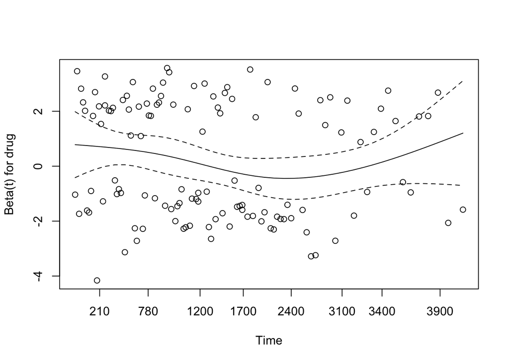

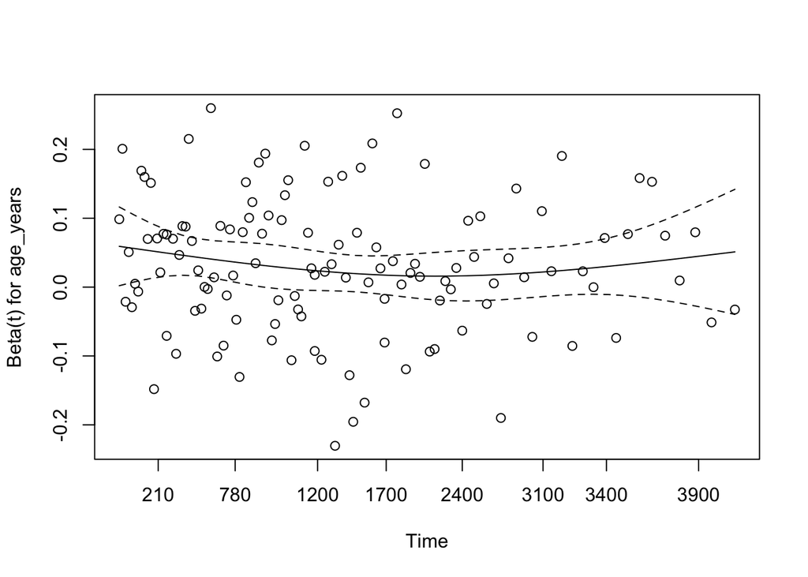

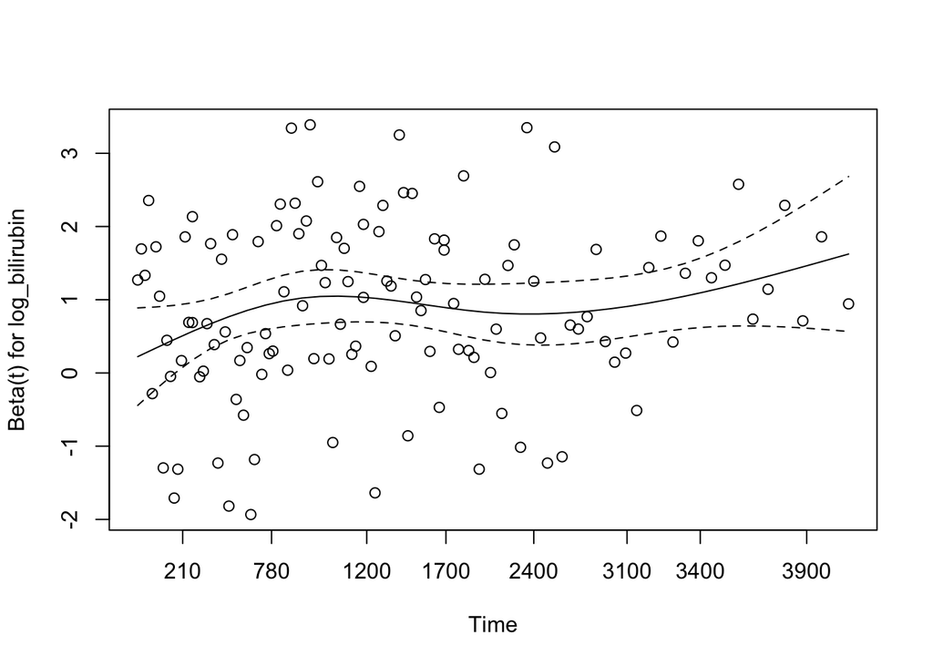

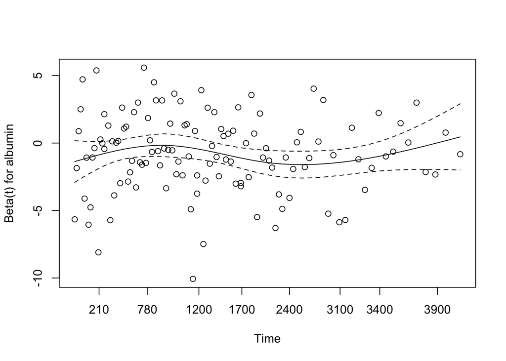

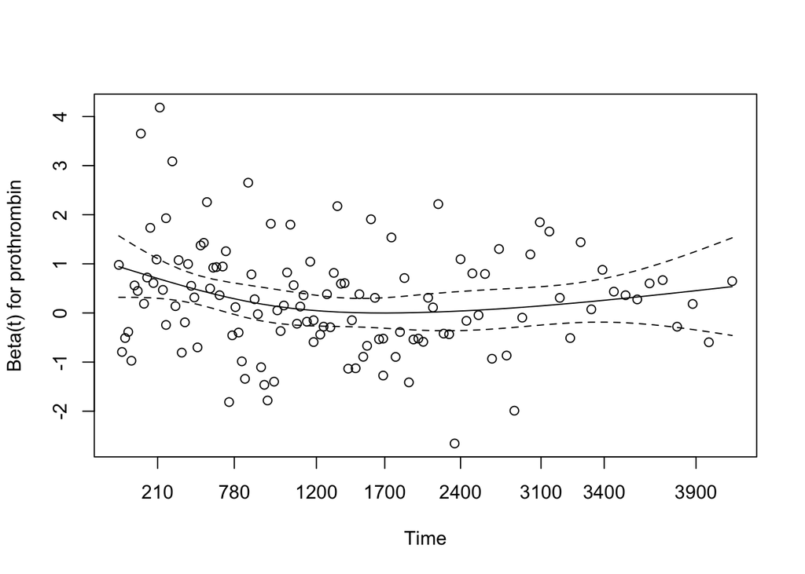

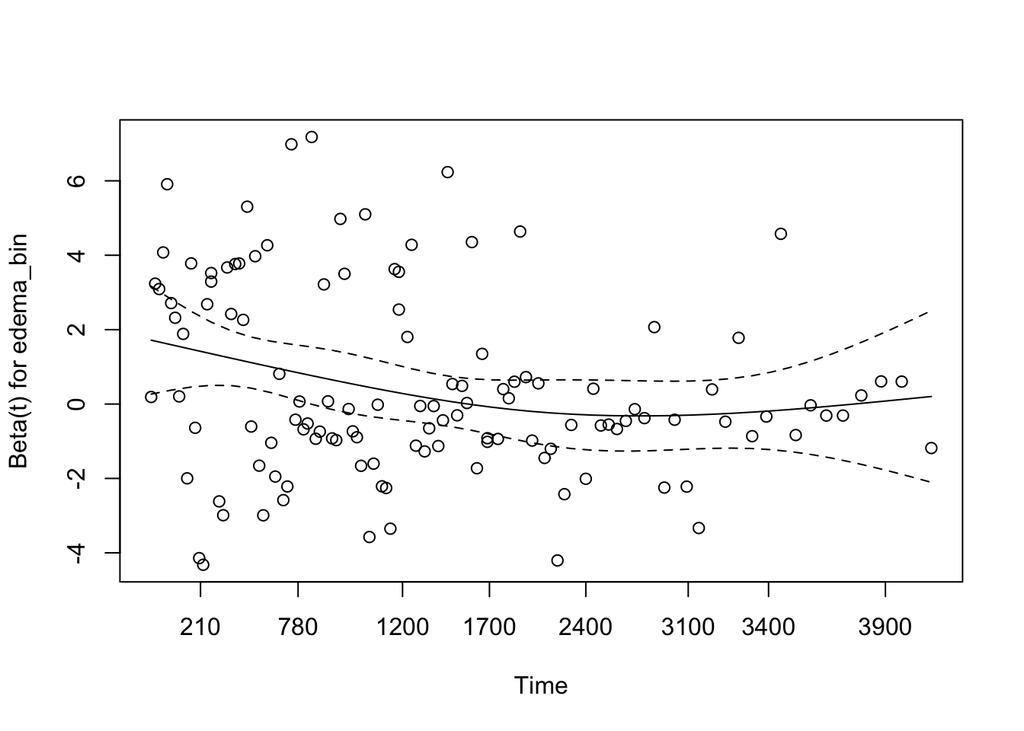

```r
plot(ph_final)
```